# Rating Blood - What attribute predicts the average rating of horror movies?

Bence Gergely

2022-12-05

## Introduction

This is a data analysis project based on the Tidy Tuesday dataset called Horror Movies (2022-11-01). In this project we are interested in what predicts the average rating of the viewers. First we are going to read the dataset, then we will clean and explore it. Based on the overviews we will explore the main topics of the films using a Latent Dirichlet Allocator. Then we will fit a linear model with the average rating being the dependent variable and the predictors chosen from the dataset.

## Dependencies

In this project we mainly use packages from tidyverse when it comes to data wrangling. The topic modelling will be made with topicmodels and for the linear model we will use the lm function.

```r
library(qgraph)
library(tidyverse)
library(tidytuesdayR)
library(tidytext)
library(topicmodels)
library(car)
```

## Reading the dataset

We will use the built in tool to load tidy tuesday data.

```r
tt_horror_data = tt_load("2022-11-01")
df = as.data.frame(tt_horror_data[[1]])
```

## Data cleaning

In this case we are going to exclude films that are unreleased, had no revenue (or no information about the revenue), had no budget (or no information about the budget) or we have no information about the movie runtime. Moreover we will not use the title, tagline, backdrop path, the collection and collection name variables.

```r
df_clean =  df %>%
              select(-title, -tagline, -poster_path, -backdrop_path, -collection, -collection_name) %>%
              filter(budget != 0 & revenue != 0 & runtime != 0 & status =="Released") %>%
              select(-status)
```

```r
genre_list = list()

#cleaning the genre variables
for(i in 1:length(df_clean[,1])){
  genre_list[[i]] = unlist(str_split(df_clean[i, "genre_names"], ", "))
}

#extracting all the genres
all_genres = unique(unlist(genre_list))
dummy_matrix = matrix(0, nrow = nrow(df_clean), ncol = length(all_genres))
colnames(dummy_matrix) = all_genres

#filling the dummy matrix with entries
for(k in 1:length(genre_list)){
  for(l in all_genres){
    dummy_matrix[k,l] = as.numeric(l %in% genre_list[[k]])
  }
}

# printing out the count of each genres
print(colSums(dummy_matrix))
```

```
##          Horror         Mystery        Thriller Science Fiction           Drama
##            1073             235             519             200             157
##          Action         Fantasy          Comedy       Animation          Family
##             126             122             162               6               4
##           Crime       Adventure        TV Movie         Romance             War
##              61              44               1              24               3
##         History         Western           Music     Documentary
##               4               2               7               2
```

```r
#creating a dataframe and binding it to the cleaned data

dummy_dataframe = as.data.frame(dummy_matrix)
df_clean = cbind(df_clean, dummy_dataframe)
```

We are creating a new variable from the budget and revenue which will represent the difference between the revenue and the budget.

```r
df_clean = df_clean %>%
              mutate(box_office_difference = revenue - budget)
```

We extract the years of the films.

```r
df_clean = df_clean %>%
              mutate(release_year = lubridate::year(release_date),
                     release_month = lubridate::month(release_date)) %>%
              mutate(release_rank = rank(release_year))
```

## Exploratory data analyis

First we present the mean and standard deviation of the box office difference, and the rating variable, the minimum, maximum, range, median and median absolute deviation of the year variable.

```r
#box_office difference descriptive statistics
bo_diff = as.vector(df_clean[,"box_office_difference"])

mean_bo_diff = mean(bo_diff, na.rm = TRUE)
sd_bo_diff = sd(bo_diff, na.rm = TRUE)
min_bo_diff = min(bo_diff)
max_bo_diff = max(bo_diff)

#rating descriptive statistics
rating = as.vector(df_clean[, "vote_average"])

mean_rating = mean(rating, na.rm = TRUE)
sd_rating = sd(rating, na.rm = TRUE)
min_rating = min(rating)
max_rating = max(rating)


#creating table for the variables
report1 = data.frame(descriptives = c("mean", "standard_deviation", "minimum", "maximum"),
                     value_bo_diff = c(mean_bo_diff, sd_bo_diff, min_bo_diff, max_bo_diff),
                     value_rating = c(mean_rating, sd_rating, min_rating, max_rating))

print(report1)
```

```
##         descriptives value_bo_diff value_rating
## 1               mean      26475325     5.788910
## 2 standard_deviation      60330795     1.695637
## 3            minimum    -194775779     0.000000
## 4            maximum     666842551    10.000000
```

```r
#year descriptive statistics
year = as.vector(df_clean[, "release_year"])

min_year = min(year)
max_year = max(year)
range_year = max_year - min_year
median_year = median(year)
mad_year = mad(year)

#creating a table for the year
report2 = data.frame(descriptives = c("median", "median_abs_deviation", "minimum", "maximum", "range"),
                     values_year = c(median_year, mad_year, min_year, max_year, range_year))

print(report2)
```

```
##           descriptives values_year
## 1               median   2007.0000
## 2 median_abs_deviation     13.3434
## 3              minimum   1953.0000
## 4              maximum   2022.0000
## 5                range     69.0000
```

```r
#mean differences per genre
genres = df_clean %>%
          select(vote_average, Mystery:Comedy, Crime)

avg_mystery = genres %>%
                group_by(Mystery) %>%
                summarise(Mystery = mean(vote_average))

avg_thriller = genres %>%
                group_by(Thriller) %>%
                summarise(Thriller = mean(vote_average))

avg_scifi = genres %>%
                group_by(`Science Fiction`) %>%
                summarise(Scifi = mean(vote_average))

avg_drama = genres %>%
                group_by(Drama) %>%
                summarise(Drama = mean(vote_average))

avg_action = genres %>%
                group_by(Action) %>%
                summarise(Action = mean(vote_average))

avg_comedy  = genres %>%
                group_by(Comedy) %>%
                summarise(Comedy = mean(vote_average))

mean_differences_per_genre = cbind(avg_scifi, avg_mystery, avg_thriller, avg_drama, avg_action, avg_comedy)
colnames(mean_differences_per_genre)[1] = "genre (no/yes)"
print(mean_differences_per_genre)
```

```
##   genre (no/yes)    Scifi  Mystery Thriller    Drama   Action   Comedy
## 1              0 5.730928 5.722792 5.707040 5.742031 5.786906 5.758727
## 2              1 6.042000 6.024681 5.876301 6.062420 5.803968 5.958642
```

```r
#averages for all possible combinations
avg_cross_prod = genres %>%
                  group_by(`Science Fiction`, Action, Comedy, Thriller, Mystery, Drama) %>%
                  summarise(overall = mean(vote_average))

print(avg_cross_prod)
```

```
## # A tibble: 40 × 7
## # Groups:   Science Fiction, Action, Comedy, Thriller, Mystery [26]
##    `Science Fiction` Action Comedy Thriller Mystery Drama overall
##                <dbl>  <dbl>  <dbl>    <dbl>   <dbl> <dbl>   <dbl>
##  1                 0      0      0        0       0     0    5.19
##  2                 0      0      0        0       0     1    5.96
##  3                 0      0      0        0       1     0    6.31
##  4                 0      0      0        0       1     1    6.07
##  5                 0      0      0        1       0     0    5.76
##  6                 0      0      0        1       0     1    6.06
##  7                 0      0      0        1       1     0    5.93
##  8                 0      0      0        1       1     1    5.55
##  9                 0      0      1        0       0     0    5.95
## 10                 0      0      1        0       0     1    6.7
## # … with 30 more rows
```

Last we are going to plot the relationship of the Year and the average rating, and we are going to colour code the box_office_diff variable

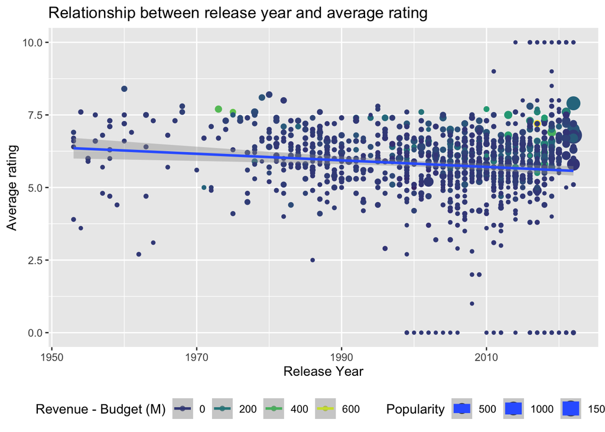

```r
#creating the plot
p = ggplot(df_clean, aes(x = release_year, y = vote_average, colour = box_office_difference / 1000000, size = popularity)) +
      geom_point() + geom_smooth(method = "lm")

#designing the plot
p = p + ggtitle("Relationship between release year and average rating") +
      xlab("Release Year") +
      ylab("Average rating") +
      scale_color_viridis_c() +
      guides(colour = guide_legend(title="Revenue - Budget (M)")) +
      guides(size = guide_legend(title="Popularity")) +
      theme(legend.position = "bottom")
p
```

## Exploratory analysis 3: Topic modeling

We are going to perform an LDA (Latent Dirichlet Allocator), to extract the topics. Evaluating the goodness of the classification in the case of LDA is relatively demanding, as you can either perform multiple fits with similar settings and examine the variability of the topics, or one can perform a qualitative fit evaluation with multiple raters. Or there are versions of this algorithm which can also estimate the number of topics based on the data using Reversible Jump MCMC, but that can be time consuming.

So for this analysis we will treat LDA as an explorative analysis step.

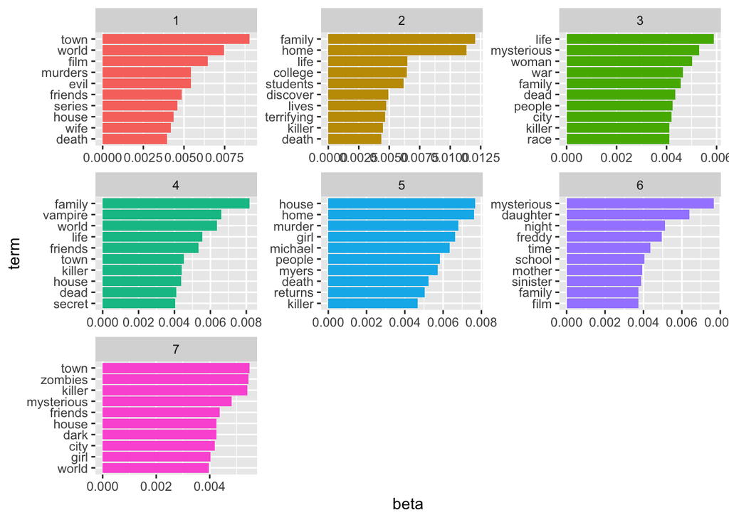

```r
#select title and overview variables
df_LDA = df_clean %>%
          select(original_title, overview)

#tokenize the overviews per movie
by_word = df_LDA %>%
            unnest_tokens(word, overview)

#find the document word counts
word_counts = by_word %>%
                anti_join(stop_words) %>%
                count(original_title, word, sort = TRUE)

#fit the Latent  Dirichlet Allocator
overview_dtm = word_counts %>%
                cast_dtm(original_title, word, n)

overview_LDA = LDA(overview_dtm, k = 7)

#understanding the results

overview_topics <- tidy(overview_LDA, matrix = "beta")

#finding the top terms of the overviews
top_terms = overview_topics %>%
              group_by(topic) %>%
              slice_max(beta, n = 10) %>%
              ungroup() %>%
              arrange(topic, -beta)

top_terms %>%
  mutate(term = reorder_within(term, beta, topic)) %>%
  ggplot(aes(beta, term, fill = factor(topic))) +
  geom_col(show.legend = FALSE) +
  facet_wrap(~ topic, scales = "free") +
  scale_y_reordered()
```

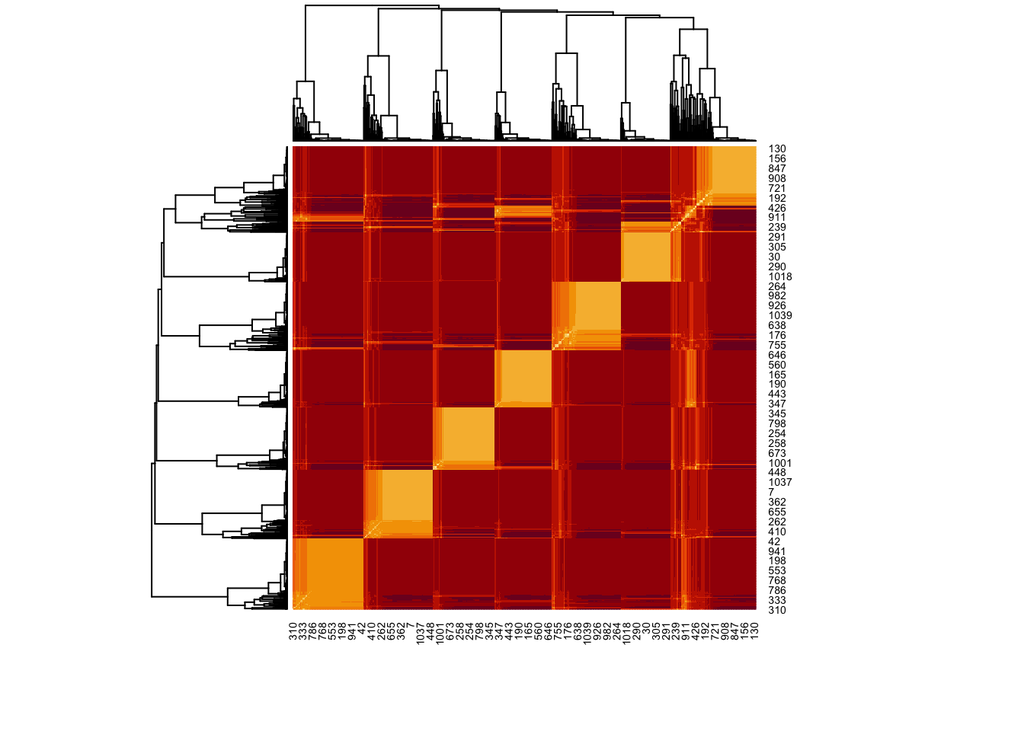

```r
#plotting the similarities of movies
overview_gamma <- tidy(overview_LDA, matrix = "gamma")
gamma_wide = overview_gamma %>% pivot_wider(names_from = topic, values_from = gamma)
distance_gamma = as.matrix(dist(gamma_wide[,2:8]))
diag(distance_gamma) = 0
heatmap(distance_gamma)
```

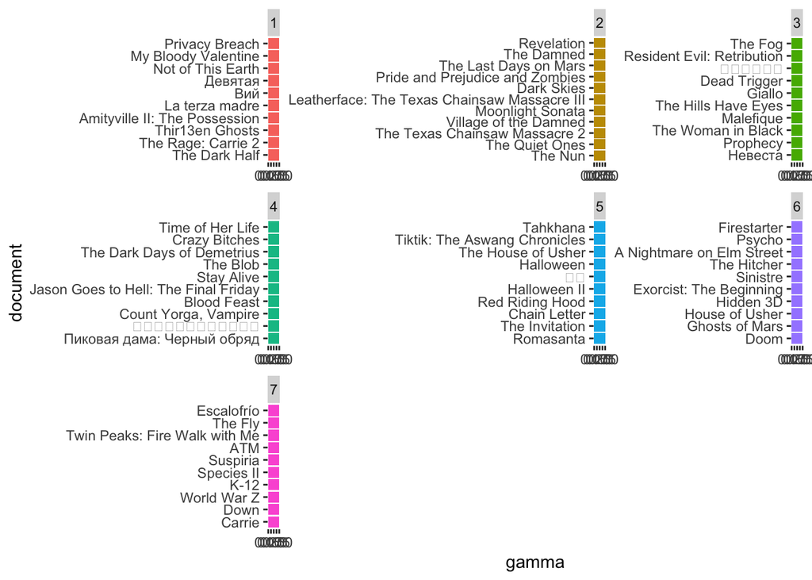

```r
#plotting tthe top movies at each created topic category
top_films = overview_gamma %>%
              group_by(topic) %>%
              slice_max(gamma, n = 10) %>%
              ungroup() %>%
              arrange(topic, -gamma)

top_films %>%
  mutate(document = reorder_within(document, gamma, topic)) %>%
  ggplot(aes(gamma, document, fill = factor(topic))) +
  geom_col(show.legend = FALSE) +
  facet_wrap(~ topic, scales = "free") +
  scale_y_reordered()
```

Based on the heatmap, we can see that the algorithm creates 7 relatively distinct categories, and the categories are more or less similar in size.

## Linear Model

### Fitting the model

```r
mod1 = lm(vote_average ~ popularity + runtime + Mystery + Thriller + Drama + Action + Comedy + `Science Fiction` + box_office_difference + release_year, data = df_clean)

summary(mod1)
```

```
##
## Call:
## lm(formula = vote_average ~ popularity + runtime + Mystery +
##     Thriller + Drama + Action + Comedy + `Science Fiction` +
##     box_office_difference + release_year, data = df_clean)
##
## Residuals:
##     Min      1Q  Median      3Q     Max
## -5.8994 -0.4310  0.1411  0.6913  5.9652
##
## Coefficients:
##                         Estimate Std. Error t value Pr(>|t|)
## (Intercept)            2.877e+01  7.112e+00   4.046 5.60e-05 ***
## popularity             1.733e-03  6.265e-04   2.766 0.005776 **
## runtime                1.184e-02  2.198e-03   5.387 8.83e-08 ***
## Mystery                3.094e-01  1.239e-01   2.496 0.012706 *
## Thriller               1.935e-01  1.046e-01   1.850 0.064597 .
## Drama                  2.942e-01  1.423e-01   2.068 0.038917 *
## Action                -2.397e-02  1.608e-01  -0.149 0.881563
## Comedy                 4.977e-01  1.460e-01   3.410 0.000674 ***
## `Science Fiction`      2.935e-01  1.349e-01   2.176 0.029798 *
## box_office_difference  4.161e-09  8.597e-10   4.840 1.49e-06 ***
## release_year          -1.228e-02  3.538e-03  -3.469 0.000542 ***
## ---
## Signif. codes:  0 '***' 0.001 '**' 0.01 '*' 0.05 '.' 0.1 ' ' 1
##
## Residual standard error: 1.608 on 1062 degrees of freedom
## Multiple R-squared:  0.1092, Adjusted R-squared:  0.1008
## F-statistic: 13.02 on 10 and 1062 DF,  p-value: < 2.2e-16
```

```r
vif(mod1)
```

```
##            popularity               runtime               Mystery
##              1.090740              1.133420              1.090608
##              Thriller                 Drama                Action
##              1.133969              1.049895              1.112536
##                Comedy     `Science Fiction` box_office_difference
##              1.133380              1.145373              1.115478
##          release_year
##              1.145430
```

### Regression diagnostics

Based on the residuals vs fitted plot the linear relationship assumption is violated. Similarly the normality of the residuals is also violated (Normal Q-Q plot), this is also true for the homoscedasticity (Scale location). Based on the Residuals vs Leverage plots, there are multiple outliers, but in this case we are not going to filter them out.

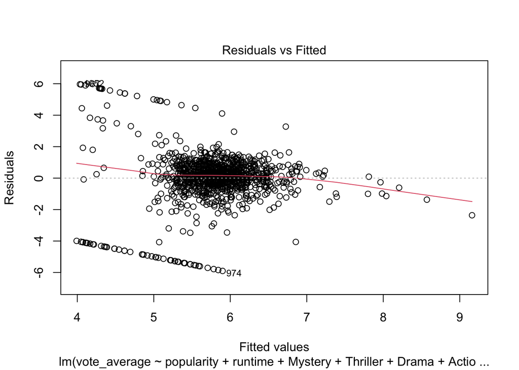

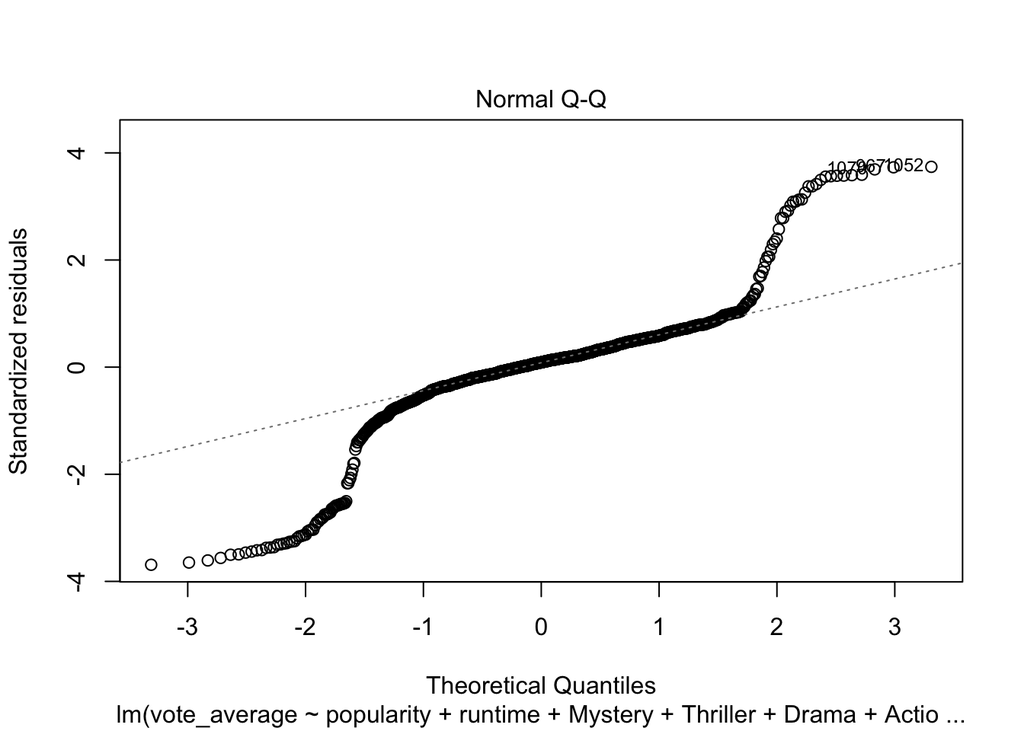

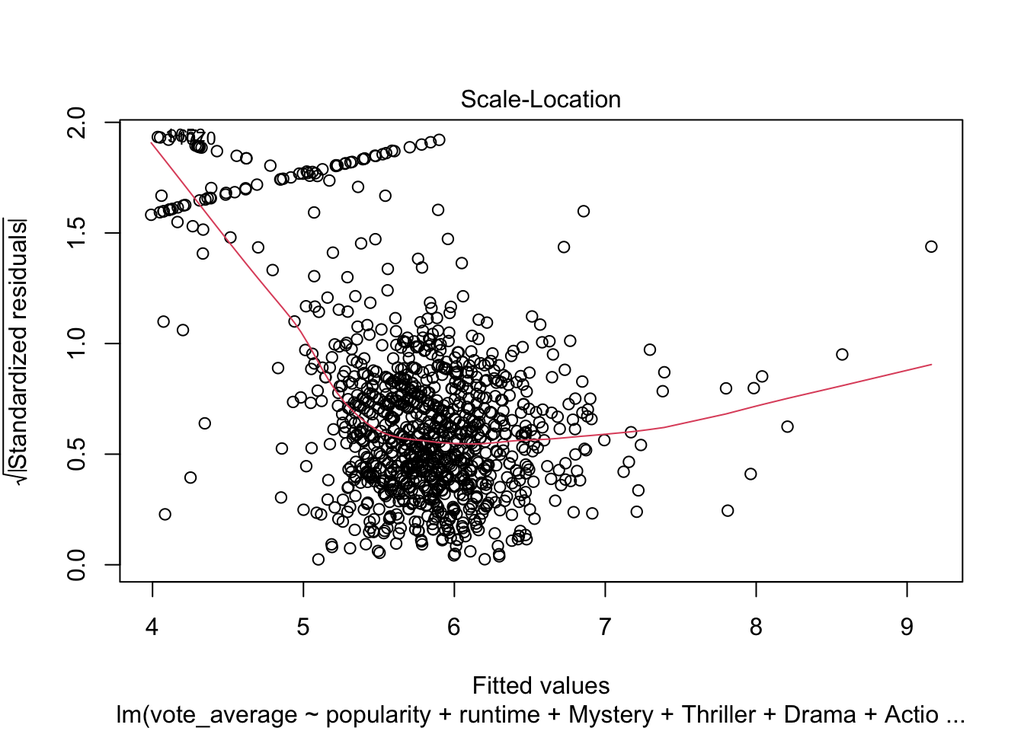

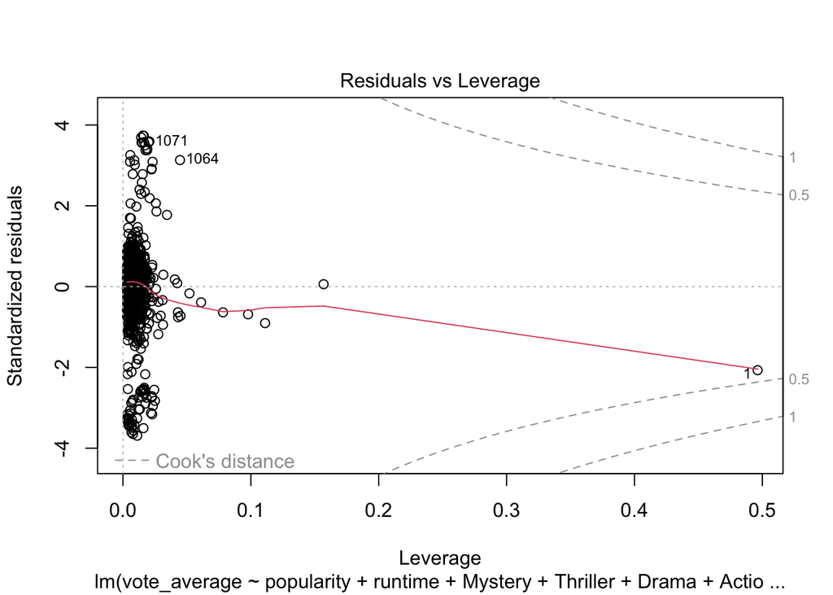

```r
plot(mod1)
```

## Discussion In this report we analysed the Horror Movies dataset from the Tidy Tuesday library. First, we cleaned the data and performed exploratory data analysis (plotting, descriptives and topic modeling of the textual data), then we fitted a linear model.